# 23_analysis

Adrian Stanciu & Ranjit Singh

26 January, 2022

# About output

When performing analyses in `R` we get as output a summary of results, which is informative but not always what we might need.

For instance.

The output of the test `cor.test()` holds rich information that we might want to store for further analyses. Or, we might want to have a select set of reported coefficients when we calculate correlations between same variables across a multitude of data sets (for instance in replication projects).

```r
# copied from 22_descriptives section
###
# Pearson's r correlation coefficient
pearson_r_ep03_ls01_v2 <- cor.test(df_allbus$ep03, # defines variable 1
                           df_allbus$ls01, # defines variable 2
                           method="pearson", # defines which correlation type to calculate
                           use="complete.obs") # specifies that missing data should not be considered
pearson_r_ep03_ls01_v2
```

```
##
##  Pearson's product-moment correlation
##
## data:  df_allbus$ep03 and df_allbus$ls01
## t = -30.059, df = 3470, p-value < 2.2e-16
## alternative hypothesis: true correlation is not equal to 0
## 95 percent confidence interval:
##  -0.4805284 -0.4277315
## sample estimates:
##        cor
## -0.4545291
```

If for any reason we want to store the `t`-test value, `p`-value and so on in a vector or a data frame, that can be (relatively) easy done. We need to call the location in the created output object of the coefficient of interest. See below:

```r
# identify the place of the desired coefficient.
# we can do this by first calling the STRucture of that object using the command str()
str(pearson_r_ep03_ls01_v2)
```

```
## List of 9
##  $ statistic  : Named num -30.1
##   ..- attr(*, "names")= chr "t"
##  $ parameter  : Named int 3470
##   ..- attr(*, "names")= chr "df"
##  $ p.value    : num 1.25e-176
##  $ estimate   : Named num -0.455
##   ..- attr(*, "names")= chr "cor"
##  $ null.value : Named num 0
##   ..- attr(*, "names")= chr "correlation"
##  $ alternative: chr "two.sided"
##  $ method     : chr "Pearson's product-moment correlation"
##  $ data.name  : chr "df_allbus$ep03 and df_allbus$ls01"
##  $ conf.int   : num [1:2] -0.481 -0.428
##   ..- attr(*, "conf.level")= num 0.95
##  - attr(*, "class")= chr "htest"
```

```r
# we will get an output with varying lines, and some of them begin with the symbol $
# the symbol $ specifices an element stored in the object that can be...called as a separate object.
# see below

# stores the t-test value
t_value_ep03_ls01 <- pearson_r_ep03_ls01_v2$statistic
# stores the p-value and at the same time rounds to nearest 2 decimals
p_value_ep03_ls01 <- pearson_r_ep03_ls01_v2$p.value %>% round(2)

# calls the t- and p-values
t_value_ep03_ls01
```

```
##         t
## -30.05934
```

```r
p_value_ep03_ls01
```

```
## [1] 0
```

Fancier stuff.

We can make an output more human-readable by tidying-up it a little. This `broom::tidy()` can help. It is the function `tidy()` from the package `broom` that comes as part of the general `tidyverse` package. So, once you’ve installed `tidyverse`, you will have access to all functions of the `broom` package.

```r
# the output from above but in a tidier format
pearson_r_ep03_ls01_v2 %>%
  broom::tidy()
```

```
## # A tibble: 1 x 8
##   estimate statistic   p.value parameter conf.low conf.high method   alternative
##      <dbl>     <dbl>     <dbl>     <int>    <dbl>     <dbl> <chr>    <chr>
## 1   -0.455     -30.1 1.25e-176      3470   -0.481    -0.428 Pearson~ two.sided
```

We can further edit the results so it gets increasingly human-readable.

```r
## we can install an extra package - kableExtra
##
if (!require(kableExtra)) {
    install.packages("kableExtra")
    require(kableExtra)
}

# activates package
library(kableExtra)

##
pearson_r_ep03_ls01_v2 %>%
  broom::tidy() %>%
  t() %>%
  kable() %>%
  kable_styling()
```

| estimate | -0.4545291 |
| --- | --- |
| statistic | -30.05934 |
| p.value | 1.246855e-176 |
| parameter | 3470 |
| conf.low | -0.4805284 |
| conf.high | -0.4277315 |
| method | Pearson’s product-moment correlation |
| alternative | two.sided |

# t-tests

As a brief reminder, t-test are a formal way of examining whether means differ between groups (or from zero, or between two observations of same individuals).

In the session **22_descriptives**, we’ve seen different ways to calculate Cohen’s *d*. But Cohen’s *d* gives the effect size of a mean difference, that is how meaningful the found difference between the means of two groups is.

We calculated Cohen’s *d* for the difference between men and women on their intention to vote for the Greens at the next German elections.

```r
# calculates cohen's d for the group comparison men~women on intention to vote for greens
cohen_d_sex_pv22 <- psych::cohen.d(df_allbus$pv22,
                                   group=df_allbus$sex)
```

But now we would like to have a formal test of whether the found difference is statistically significant, albeit a small one as the Cohen’s *d* informs. For this, we can use the t-test from the package `infer` (comes with tidyverse general package).

```r
# t-test
t_test_pv22_sex <- df_allbus %>%
  infer::t_test(pv22 ~ sex)
```

Let’s call together the Cohen’s *d* and t-test results.

```r
cohen_d_sex_pv22
```

```
## Call: psych::cohen.d(x = df_allbus$pv22, group = df_allbus$sex)
## Cohen d statistic of difference between two means
##      lower effect upper
## [1,]  0.11   0.18  0.25
##
## Multivariate (Mahalanobis) distance between groups
## [1] 0.18
## r equivalent of difference between two means
## data
## 0.09
```

```r
t_test_pv22_sex
```

```
## # A tibble: 1 x 7
##   statistic  t_df     p_value alternative estimate lower_ci upper_ci
##       <dbl> <dbl>       <dbl> <chr>          <dbl>    <dbl>    <dbl>
## 1     -5.14 3261. 0.000000297 two.sided     -0.516   -0.713   -0.319
```

Now that we have this information, can we put together a table with results for our paper or report?

Remember, for this we would need:

- to create a table with new columns and empty rows - using `tibble()`
- store output results as separate objects in `R`

To report mean-differences we would need: meand difference itself, `t-value`, `df` (degrees of freedom), associated `p-value`, `ci` (confidence interval), and a measure of effect size `d`.

```r
# creates empty table
df_report <- tibble(
  output_variable = vector("character",0),
  group_variable = vector("character",0),
  mean_diff = vector("numeric",0),
  d = vector("numeric",0),
  t_value = vector("numeric",0),
  df = vector("numeric",0),
  p_value = vector("numeric",0),
  ci_up = vector("numeric",0),
  ci_low = vector("numeric",0)
  )

# identifies coefficients to fill in the empty table
# str(cohen_d_sex_pv22)
# str(t_test_pv22_sex)
# then adds row to the table

df_report <- df_report %>% add_row(
  output_variable = "pv22",
  group_variable = "sex",
  mean_diff = t_test_pv22_sex$estimate,
  t_value = t_test_pv22_sex$statistic,
  df = t_test_pv22_sex$t_df,
  p_value = t_test_pv22_sex$p_value,
  ci_up = t_test_pv22_sex$upper_ci,
  ci_low = t_test_pv22_sex$lower_ci,
  d = cohen_d_sex_pv22$cohen.d[2]
)

# show results
df_report %>% kable() %>% kable_styling()
```

| output_variable | group_variable | mean_diff | d | t_value | df | p_value | ci_up | ci_low |
| --- | --- | --- | --- | --- | --- | --- | --- | --- |
| pv22 | sex | -0.5163108 | 0.1793207 | -5.135932 | 3260.516 | 3e-07 | -0.3192042 | -0.7134175 |

This is extremely useful to keep your results organized as you progress with your analyses. Also see the exercise below.

## Exercise

Add a new row to the table **df_report** with the information from mean comparison between german and non-german (`german`) and the intention to vote for SPD (`pv20`).

Remember the steps:

- perform t-test
- calculate Cohen’s *d*
- inspect the output and identify the coefficients of interest
- add the new row to the df_report table

```r
## to be deleted: key to exercise
# cohen d
cohen_d_german_pv20 <- psych::cohen.d(df_allbus$pv20,
                                   group=df_allbus$german)

# t-test
t_test_pv20_german <- df_allbus %>%
  infer::t_test(pv20 ~ german)
# populate result table
df_report <- df_report %>% add_row(
  output_variable = "pv20",
  group_variable = "german",
  mean_diff = t_test_pv20_german$estimate,
  t_value = t_test_pv20_german$statistic,
  df = t_test_pv20_german$t_df,
  p_value = t_test_pv20_german$p_value,
  ci_up = t_test_pv20_german$upper_ci,
  ci_low = t_test_pv20_german$lower_ci,
  d = cohen_d_german_pv20$cohen.d[2]
)

# show table
df_report %>% kable() %>% kable_styling()
```

| output_variable | group_variable | mean_diff | d | t_value | df | p_value | ci_up | ci_low |
| --- | --- | --- | --- | --- | --- | --- | --- | --- |
| pv22 | sex | -0.5163108 | 0.1793207 | -5.135932 | 3260.5163 | 0.0000003 | -0.3192042 | -0.7134175 |
| pv20 | german | -0.4622920 | 0.1642206 | -1.824323 | 138.6041 | 0.0702569 | 0.0387466 | -0.9633307 |

# Regression

## OLS

Simple regression, or the OLS regression, is one whereby one dependent variable is regressed on one independent variable. The simplest form of regression is in many ways similar to a correlation between two continuous variables.

Multiple regressions on the other hand regresses one dependent variables on multiple independent variables.

Let us revisit a correlation coefficient we’ve looked at in the session `22_descriptives`. We correlated `ep03` (Respondent’s current financial situation) with `ls01` (Overall life satisfaction of respondent).

```r
# Pearson's r correlation coefficient
pearson_r_ep03_ls01_v2
```

```
##
##  Pearson's product-moment correlation
##
## data:  df_allbus$ep03 and df_allbus$ls01
## t = -30.059, df = 3470, p-value < 2.2e-16
## alternative hypothesis: true correlation is not equal to 0
## 95 percent confidence interval:
##  -0.4805284 -0.4277315
## sample estimates:
##        cor
## -0.4545291
```

```r
# regresses ls01 on ep03
reg_ls01_ep03 <- df_allbus %>%
  lm(ls01 ~ ep03,.)

# calls the output of the regression
summary(reg_ls01_ep03)
```

```
##
## Call:
## lm(formula = ls01 ~ ep03, data = .)
##
## Residuals:
##     Min      1Q  Median      3Q     Max
## -9.0995 -1.0696 -0.0846  0.9154  4.9603
##
## Coefficients:
##             Estimate Std. Error t value Pr(>|t|)
## (Intercept) 10.11445    0.08147  124.14   <2e-16 ***
## ep03        -1.01495    0.03376  -30.06   <2e-16 ***
## ---
## Signif. codes:  0 '***' 0.001 '**' 0.01 '*' 0.05 '.' 0.1 ' ' 1
##
## Residual standard error: 1.569 on 3470 degrees of freedom
##   (5 observations deleted due to missingness)
## Multiple R-squared:  0.2066, Adjusted R-squared:  0.2064
## F-statistic: 903.6 on 1 and 3470 DF,  p-value: < 2.2e-16
```

We can also visualize the regression whereby we first build a scatter plot and draw a regression line to the plot.

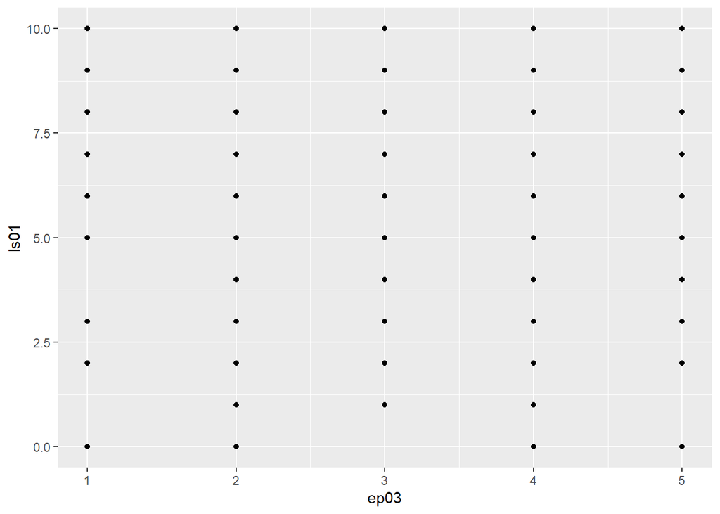

```r
p_scatter_1 <- df_allbus %>%
  ggplot(aes(y=ls01,
             x=ep03)) +
  geom_point()

p_scatter_1
```

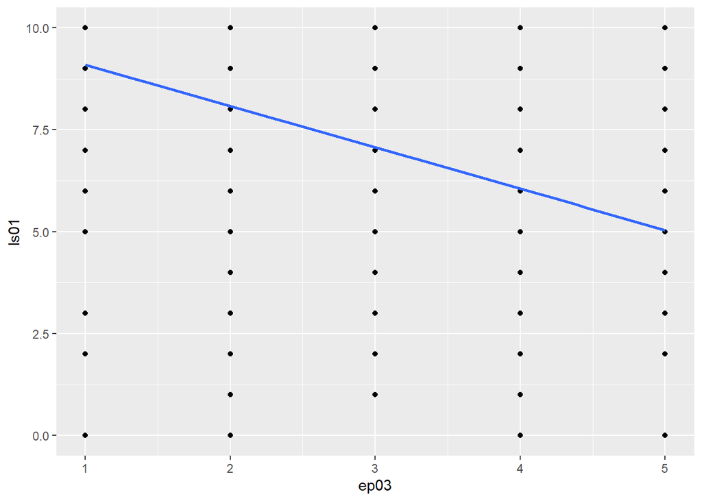

```r
# scatter plot with regression line
p_scatter_2 <- df_allbus %>%
  ggplot(aes(x=ep03,y=ls01)) +
  geom_point() +
  geom_smooth(method="lm",se=FALSE)

p_scatter_2
```

This might not look too intuitive. Let us try again with the aggregated index we’ve created in session 22_descriptives. And now let us first regress voting intention for the German government (the aggregated index over `pv20`, `pv21` and `pv22`) on self-placement on left-right spectrum (`pa01`).

```r
# creates data frame containing only the variables of interest
df_reg_2 <- df_allbus %>%
  mutate(vote_int=(pv20+pv21+pv22)/3) %>%
  select(pa01,vote_int)

# estimates the gression model
reg_pa01_vot_int <- df_reg_2 %>%
  lm(vote_int ~ pa01,.)

# calls the output of the regression
summary(reg_pa01_vot_int)
```

```
##
## Call:
## lm(formula = vote_int ~ pa01, data = .)
##
## Residuals:
##     Min      1Q  Median      3Q     Max
## -5.0149 -1.2940  0.1789  1.3727  5.5665
##
## Coefficients:
##             Estimate Std. Error t value Pr(>|t|)
## (Intercept)  6.27849    0.10566   59.42   <2e-16 ***
## pa01        -0.26357    0.02026  -13.01   <2e-16 ***
## ---
## Signif. codes:  0 '***' 0.001 '**' 0.01 '*' 0.05 '.' 0.1 ' ' 1
##
## Residual standard error: 1.932 on 3158 degrees of freedom
##   (317 observations deleted due to missingness)
## Multiple R-squared:  0.05084,    Adjusted R-squared:  0.05054
## F-statistic: 169.2 on 1 and 3158 DF,  p-value: < 2.2e-16
```

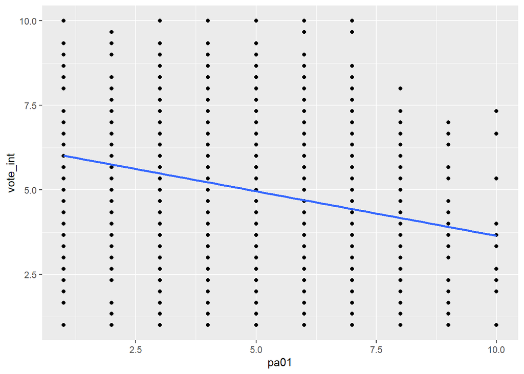

```r
# plots and then adds a regression line
p_reg_pa01_vot_int <- df_reg_2 %>%
  ggplot(aes(x=pa01,
             y=vote_int)) +
  geom_point() +
  geom_smooth(method="lm",se=FALSE)

# calls the plot with regression line
p_reg_pa01_vot_int
```

Let us clean up a bit the results output.

```r
# with function glance()
glance(reg_pa01_vot_int)
```

```
## # A tibble: 1 x 12
##   r.squared adj.r.squared sigma statistic  p.value    df logLik    AIC    BIC
##       <dbl>         <dbl> <dbl>     <dbl>    <dbl> <dbl>  <dbl>  <dbl>  <dbl>
## 1    0.0508        0.0505  1.93      169. 1.03e-37     1 -6563. 13133. 13151.
## # ... with 3 more variables: deviance <dbl>, df.residual <int>, nobs <int>
```

```r
# with function tidy()
tidy(reg_pa01_vot_int)
```

```
## # A tibble: 2 x 5
##   term        estimate std.error statistic  p.value
##   <chr>          <dbl>     <dbl>     <dbl>    <dbl>
## 1 (Intercept)    6.28     0.106       59.4 0
## 2 pa01          -0.264    0.0203     -13.0 1.03e-37
```

We can also add a factor into the regression model, so we get different estimations for each level of the factor. Here let us add `sex` (whether a participant is male or female). First, however we need to instruct `R` to treat `sex` as a factor instead of a numeric variable.

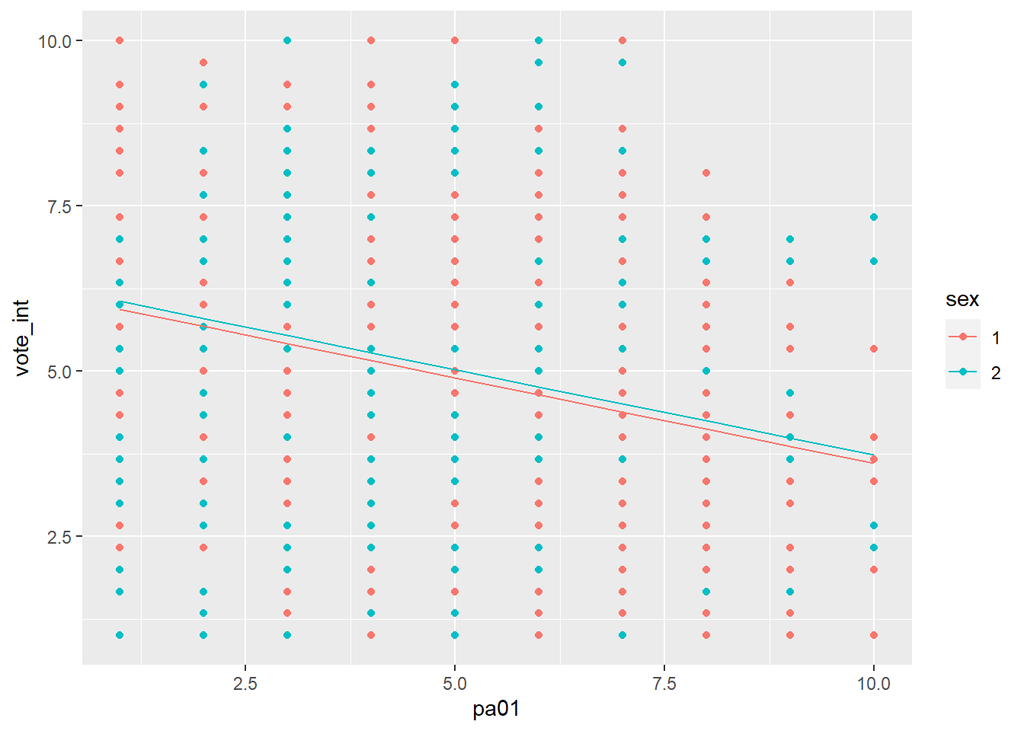

```r
# creates new data frame containing
df_reg_3 <- df_allbus %>%
    mutate(vote_int=(pv20+pv21+pv22)/3) %>%
    select(sex,pa01,vote_int)
# transforms sex into a factor variable
df_reg_3$sex <- as.factor(df_reg_3$sex)

# calculates the regression
reg_pa01_vot_int <- df_reg_3 %>%
    lm(vote_int ~ pa01 + sex,.)

# plots the results and add a regression line for each level of the factor variable
p_pa01_vot_int_fct <- reg_pa01_vot_int %>% augment() %>% ggplot(aes(color=sex))+
     geom_point(aes(pa01,vote_int))+
     geom_line(aes(pa01,.fitted))

# calls the plot
p_pa01_vot_int_fct
```

## Exercise

Imagine you are conducting a step-wise multiple regression where you want to determine whether `vote_int` (aggregated score over the voting probability for one of the three parties forming the current German government) can be regressed on `pa01` (Self-placement on left-right political spectrum) and participants`gender`sex`.

You expect that alone `pa01` explains some of the variance in `vote_int` and want to explore the role of `sex` as well.

```r
### to be deleted: this is key to exercise

# MODEL 1
# creates data frame containing only the variables of interest
df_reg_2 <- df_allbus %>%
  mutate(vote_int=(pv20+pv21+pv22)/3) %>%
  select(pa01,vote_int)

# estimates the simple ression model
# vote_int ~ pa01
model_1 <- df_reg_2 %>%
  lm(vote_int ~ pa01,.)


# MODEL 2
# creates new data frame containing
df_reg_3 <- df_allbus %>%
    mutate(vote_int=(pv20+pv21+pv22)/3) %>%
    select(sex,pa01,vote_int)
# transforms sex into a factor variable
df_reg_3$sex <- as.factor(df_reg_3$sex)

# calculates the regression
# vote_int ~ pa01 + sex
model_2 <- df_reg_3 %>%
    lm(vote_int ~ pa01 + sex,.)

# MODEL 3
model_3 <- df_reg_3 %>%
    lm(vote_int ~ pa01 * sex,.)


###

# Checks the explantory power of each model
# R square model 1
rsq_model_1 <- glance(model_1)$adj.r.squared
rsq_model_1
```

```
## [1] 0.05054387
```

```r
# R square model 2
rsq_model_2 <- glance(model_2)$adj.r.squared
rsq_model_2
```

```
## [1] 0.05118679
```

```r
# R square model 3
rsq_model_3 <- glance(model_3)$adj.r.squared
rsq_model_3
```

```
## [1] 0.05170216
```

```r
###

# compares models with F-test
model_comparison <- anova(model_1,model_2,model_3) %>%
  tidy() %>%
  add_column(model=c("model 1","model 2", "model 3")) %>% # adds a new column to indicate which model is which
  relocate(model, .before = res.df) %>% # relocates new column at the beginning of table
  add_column(r_square=c(rsq_model_1,rsq_model_2,rsq_model_3)) %>%
  relocate(r_square,.after=model)
model_comparison
```

```
## # A tibble: 3 x 8
##   model   r_square res.df    rss    df sumsq statistic p.value
##   <chr>      <dbl>  <dbl>  <dbl> <dbl> <dbl>     <dbl>   <dbl>
## 1 model 1   0.0505   3158 11784.    NA  NA       NA    NA
## 2 model 2   0.0512   3157 11772.     1  11.7      3.14  0.0764
## 3 model 3   0.0517   3156 11762.     1  10.1      2.72  0.0995
```